### Impact of Manual vs. Automatic Transmission on MPG

#### Executive Summary / Synopsis:

In this analysis, I looked at the “mtcars” Dataset. The goal of this anaysis is to assess whether or not Transmission Type {Automatic, Manual} impacts MPG. As part of this analysis, the impact of confounding factors, especially # Cylinders, on MPG is considered. The results show that when not considering other factors, the choice of Transmission Type has an impact the MPG, but after considering at least one other confounding factor, # Cylinders, the impact is not as strong, but still present.

#### Data Processing:

Only a subset of the steps for Data processing are “echoed” here (see corresponding section in the Appendix for Data Processing), as are some of the exploratory data analysis calls (head, summary), in addition to consolidating some R statements due to the report length constraints. The mtcars dataset is loaded, a lookup table for TransmissionType is created, the mtcars and the lookup dataset are joined via the merge command, and the Cyl columm is created into a Factor variable.

#### Exploratory Graphs:

Exploratory Graphs were created, with 3 generated in the Appendix under Heading “Appendix - Exploratory Graphs”. What is apparent from looking simply at “MPG vs. Transmission Type” is that Manual Transmission appears to have higher MPG than Automatics. After adding a “color” to the graph for # Cylinders, it appears that the 4 cylinder cars tend to be higher in MPG tham the 6 or 8 cylinder cars, possibly implying a confounding factor. Looking further by leveraging the “facet” argument to the qplot call, we see a clear dependency for # Cylinders and MPG in the “MPG vs. # Cylinders” graph with Transmission Type as a “facet”“, but less of a clear dependency for Transmission Type in the”MPG vs. Transmission Type" graph with # Cylinders as a “facet” (i.e. accounting for a potential confounding factor). Again, the 3 relevant Exploratory Graphs are in the corresponding section in the Appendix. Regression Model and Results follow.

#### Model / Results:

These two models are two different univariate models, with both showing a relationship between MPG and Transmission and MPG and # Cylinders. Next, we consider a multivariate model. from the Fit of MPG ~ Transsmision + CYL, the Beta0 = 14.7, which relates the Expected Value of 14.7 MPG for a car with 8 Cylinders qnd Automatic Transmission, while Beta1 = 10.1, which relates the Expected Value of 10.1 MPG increase or 24.8 MPG overall for a car with 4 Cylinders vs 8 Cylinders, in addition to Beta2 = 3.9, which relates the Expected Value of 3.9 MPG increase or 18.6 MPG overall for a car with 6 Cylinders vs 8 Cylinders, and in addition Beta3 = 2.6, which relates the Expected Value of 2.6 MPG increase or 17.3 MPG overall for a car with Manual Transmission vs Automatic Transmission - these results reflect that the choice in both Transmission and the # Cylinders has an effect on MPG.

The model choice is Fit 1, where MPG ~ Transmission + CYL - while we are trying to model the relationship between MPG and Transmission, considering Transmission only would overstate the impact Manual Transmissions have vs. Automatic Transmissions. Thus, # Cylinders is a counfounding factor, and once its impact on MPG is removed, we have a more accurate estimate of the impact of Transmission Type and MPG. There may be other counfounding factors, but for the purpose of this analysis, the concept of multivariate regresion and the concept of considering other factors also impacting the relationship between variables you are trying to model, are considered. Also, further analysis would most likely exceed the limited allowed length for this analysis.

Per the question, Manual Transmission is better for MPG than Automatic, but # Cylinders is an example of another factor impacting the MPG for a given car. Also, per the question, per the multivariate model choice (here, Fit1), the quantified difference between Manual and Automatic Transmissions is 2.6 MPG after accounting for the impact of # Cylinders.

In terms of model uncertainty, confidence intervals can be created around the model (Fit 1) coefficients {Beta0, Beta1, Beta2, Beta3}. 95% CIs can be roughly created around each coefficient by the coeff +/- 1.96 * std error, which translates to: Beta0 CI = 14.7 +/- 1.7, Beta1 CI = 10.1 +/- 2.8, Beta2 CI = 3.9 +/- 2.9, and Beta3 CI = 2.56 +/- 2.54.

Please see the corresponding Appendix section entitled “Appendix - Model / Results”.

#### Appendix:

#### Appendix 1: Data Processing:

Data processing code, due to report Length Restrictions, is included here.

```r
library(ggplot2)

# load data
data("mtcars") #head(mtcars) #summary(mtcars)

# Create a Lookup Table for Transmission Type & define factor columns
Trans <- cbind( TransID = c(0,1), TransName = c("Automatic", "Manual"))
mtcars$cylFactor <- as.factor(mtcars$cyl)
mtcars <- within(mtcars, cylFactor <- relevel(cylFactor, ref = "8"))

# merge the datasets
mtcarsTrans = merge(x = mtcars, y = Trans, by.x = "am", by.y = "TransID", x.all=TRUE)
```

#### Appendix 2: Exploratory Graphs:

Exploratory Graphs, due to report Length Restrictions, are included here.

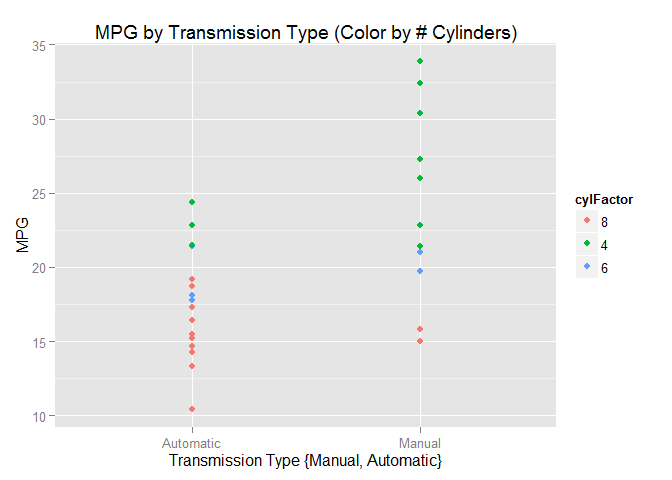

```r
# Exploratory Graphs
qplot(TransName, mpg, data = mtcarsTrans, color = cylFactor,
      main = "MPG by Transmission Type (Color by # Cylinders)",
      xlab = "Transmission Type {Manual, Automatic}", ylab = "MPG")
```

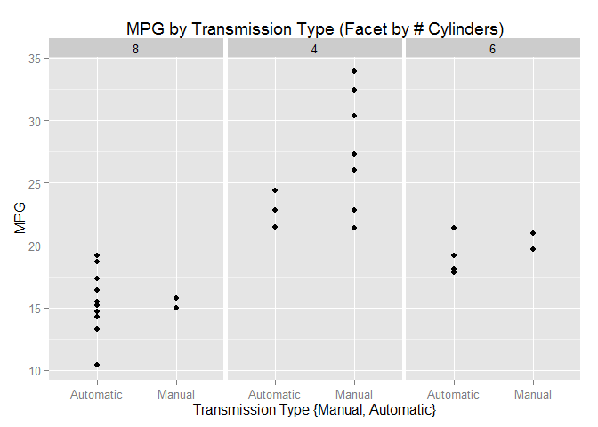

```r
qplot(TransName, mpg, data = mtcarsTrans, facets = .~ cylFactor,
      main = "MPG by Transmission Type (Facet by # Cylinders)",
      xlab = "Transmission Type {Manual, Automatic}", ylab = "MPG")
```

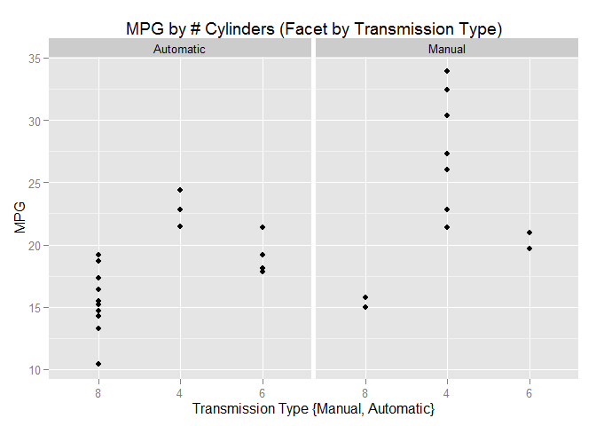

```r
qplot(cylFactor, mpg, data = mtcarsTrans, facets = .~ TransName,
      main = "MPG by # Cylinders (Facet by Transmission Type)",
      xlab = "Transmission Type {Manual, Automatic}", ylab = "MPG")
```